# tidyverse_with_gapminder

### dynamic viz

```r
by_year <- gapminder %>%
  group_by(year) %>%
  summarize(totalPop = sum(pop),
            meanLifeExp = mean(lifeExp))
```

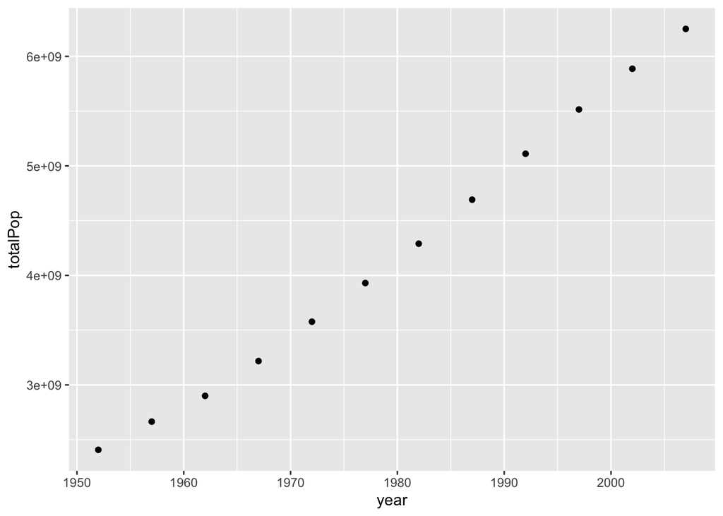

```r
# plot these summaries now
ggplot(by_year, aes(x = year, y = totalPop)) +
  geom_point()
```

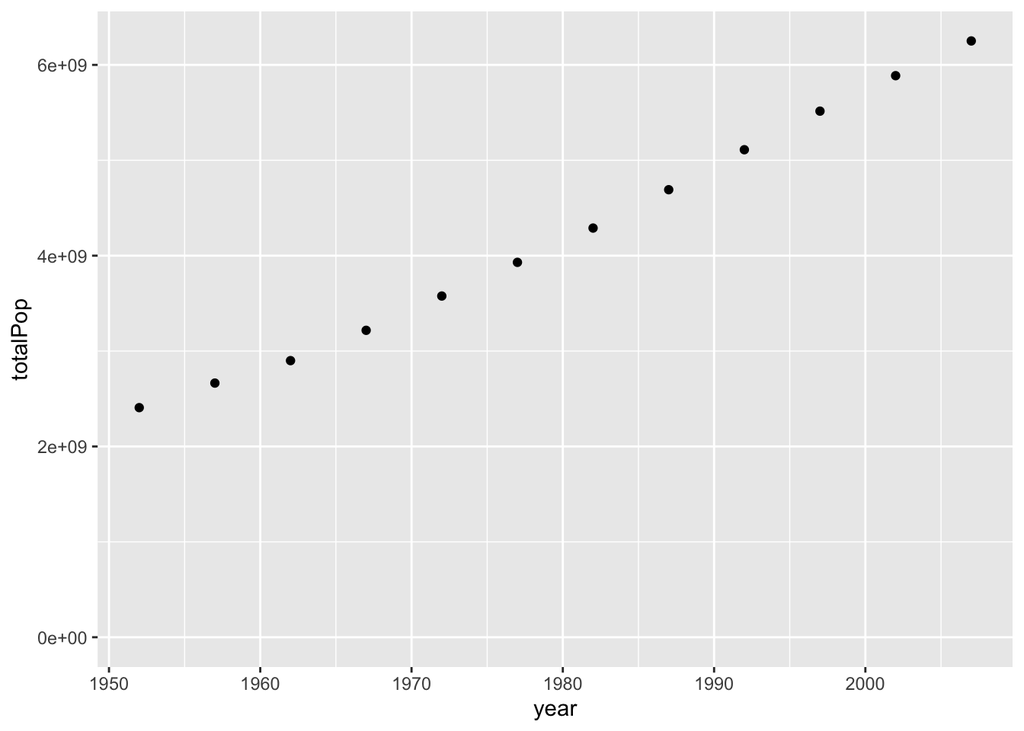

```r
# add y = 0 to the graph
ggplot(by_year, aes(x = year, y = totalPop)) +
  geom_point() +
  expand_limits(y = 0)
```

```r
# group by year, continent into new data frame
by_year_continent <- gapminder %>%
  group_by(year, continent) %>%
  summarize(totalPop = sum(pop),
            meanLifeExp = mean(lifeExp))
```

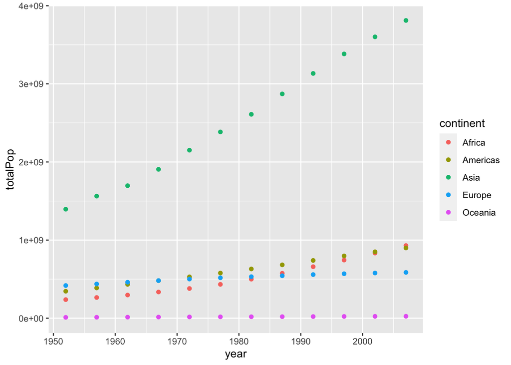

```r
ggplot(by_year_continent, aes(x = year,
                              y = totalPop,
                              color = continent)) +
  geom_point() +
  expand_limits(y = 0)
```

### Line plots

Used for time series visualization, somewhat easier than plotting points.

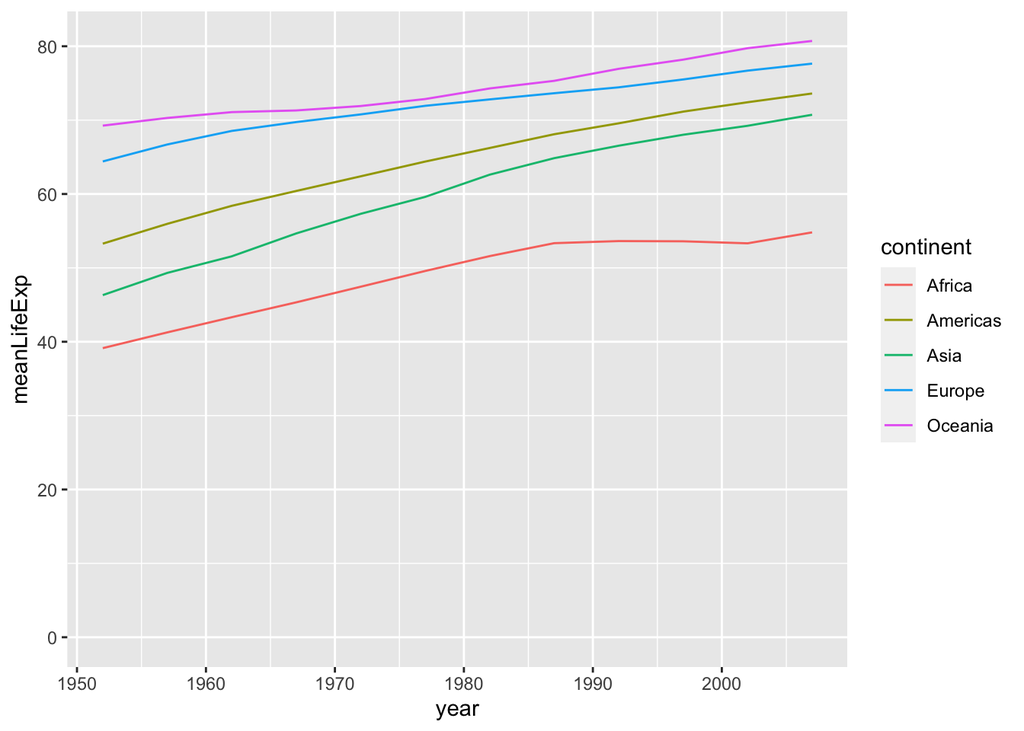

```r
ggplot(by_year_continent, aes(x = year,
                              y = meanLifeExp,
                              color = continent)) +
  geom_line() +
  expand_limits(y = 0)
```

### Bar plots

Used to display heights (y-axis) broken down by a categorical variable (x-axis).

Use this for comparative analysis.

```r
by_continent <- gapminder %>%
  group_by(continent) %>%
  summarize(totalPop = sum(pop),
            meanLifeExp = mean(lifeExp))
```

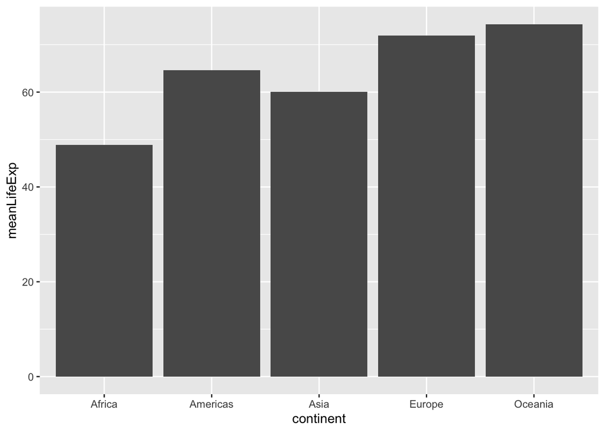

```r
ggplot(by_continent, aes(x = continent,
                         y = meanLifeExp)) +
  geom_col()
```

### Histograms

Used to look at one variable closely (on the x-axis).

Uses “bins”. You can change the bin width, the # of observations in a bin, etc.

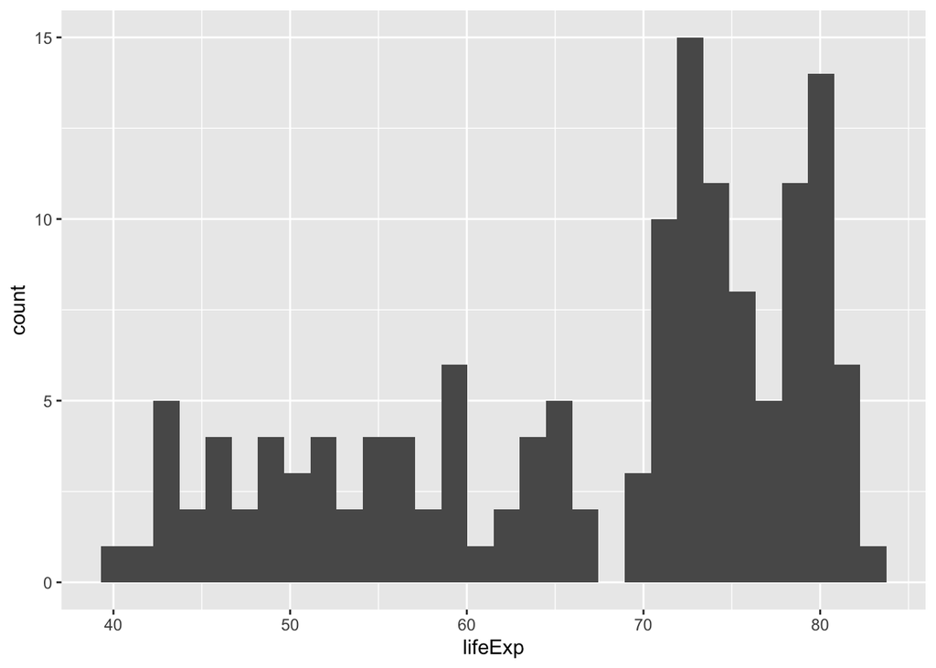

```r
ggplot(gapminder_2007, aes(x = lifeExp)) +
  geom_histogram()
```

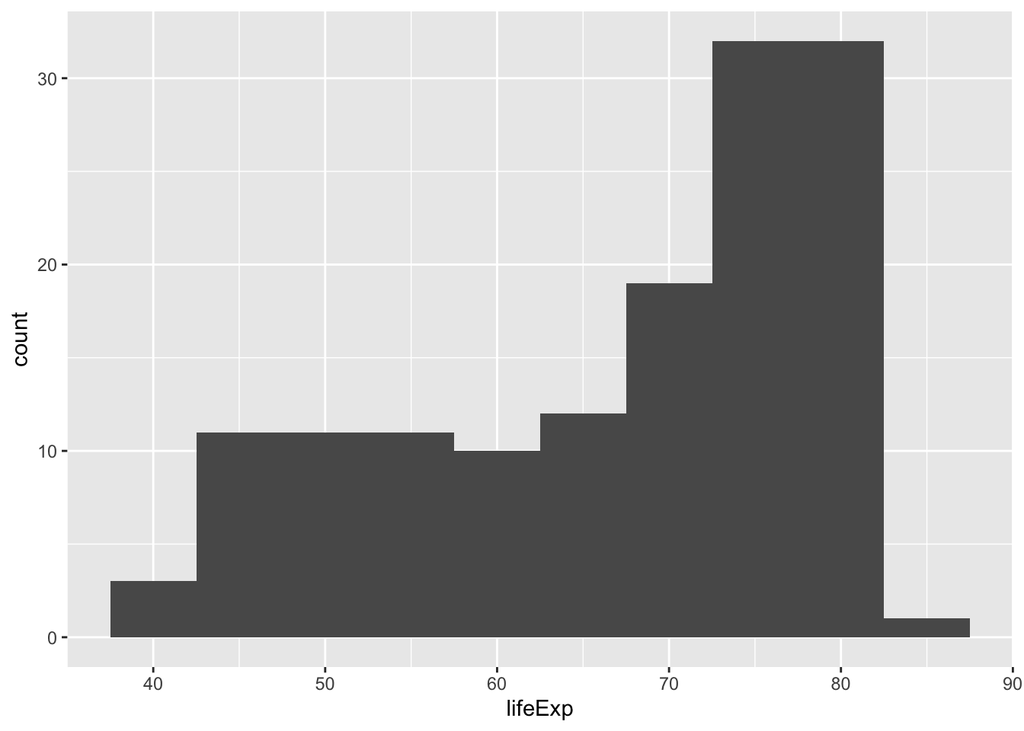

```r
# change the histogram bin width
# you can also change the # of bins, using bins = <insert #>
ggplot(gapminder_2007, aes(x = lifeExp)) +
  geom_histogram(binwidth = 5)
```

### Box plots

Used to 1) understand the distribution of a variable and 2) compare across a set of predictors against a response variable.

Breaks down into quadrants (50% shown in the “box”), shows the median (dark line) and stretches with whiskers (3rd and 4th quadrants).

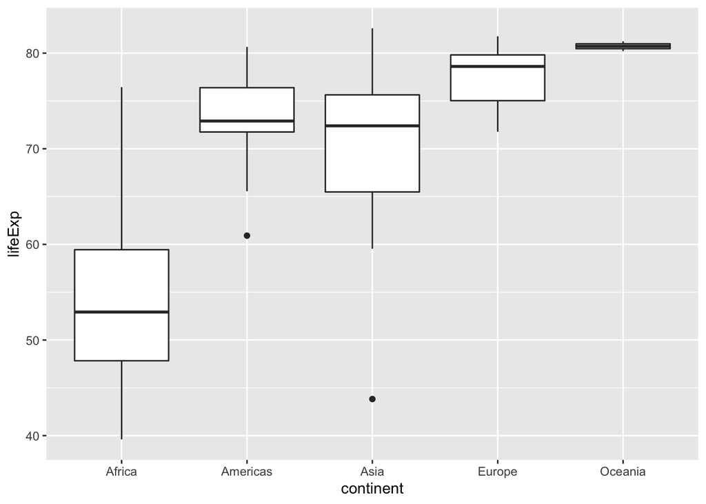

```r
ggplot(gapminder_2007, aes(x = continent, y = lifeExp)) +
  geom_boxplot()
```

```r
# add a label using labs and title
ggplot(gapminder_2007, aes(x = lifeExp)) +
  geom_histogram(binwidth = 5) +
  labs(
    title = paste(
      "Life Expectancy Across Continents"
    )
  )
```

[output not shown]

```r
# done another way
ggplot(gapminder_2007, aes(x = lifeExp)) +
  geom_histogram(binwidth = 5) +
  labs(title = "Life Expectancy Across Continents")
```

[output not shown]

```r
# using ggtitle
ggplot(gapminder_2007, aes(x = lifeExp)) +
  geom_histogram(binwidth = 5) +
  ggtitle("Life Expectancy Across Continents")
```

[output not shown]